# Final Project Code Repo

Spencer Zeigler

May 2nd, 2022

```r
knitr::opts_chunk$set(echo = TRUE, message = FALSE, warning=FALSE)

# load libraries
library(tidyverse) # Easily Install and Load the 'Tidyverse'
library(spotifyr) # R Wrapper for the 'Spotify' Web API
library(jsonlite) # A Simple and Robust JSON Parser and Generator for R
library(VIM) # Visualization and Imputation of Missing Values
library(naniar) # Data Structures, Summaries, and Visualisations for Missing Data
library(zoo) # S3 Infrastructure for Regular and Irregular Time Series (Z's Ordered Observations)
library(xts) # eXtensible Time Series
```

```r
library(corrplot) # Visualization of a Correlation Matrix
library(car) # Companion to Applied Regression
library(performance) # Assessment of Regression Models Performance
library(olsrr) # Tools for Building OLS Regression Models
library(gtable) # Arrange 'Grobs' in Tables
library(gtsummary) # Presentation-Ready Data Summary and Analytic Result Tables
library(cols4all) # Colors for all
library(patchwork) # The Composer of Plots
library(tidymodels) # Easily Install and Load the 'Tidymodels' Packages
library(tidytext) # Text Mining using 'dplyr', 'ggplot2', and Other Tidy Tools
library(citation)

#functions
source("scripts/functions.R")

# connect spotifyr to spotify developer app
Sys.setenv(SPOTIFY_CLIENT_ID = 'b98702e41ca940509e67f7b297d87c2e')
Sys.setenv(SPOTIFY_CLIENT_SECRET = 'a06b83088a974c3696875a7d9fb13114')

access_token <- get_spotify_access_token()

# general
theme_set(theme_bw())
colors <- c("#F3C300", "#875692", "#F38400", "#A1CAF1", "#BE0032", "#C2B280", "#848482", "#008856", "#E68FAC", "#0067A5")
colors2 <- c("#88CCEE", "#CC6677", "#DDCC77", "#117733", "#332288", "#AA4499", "#44AA99", "#999933", "#882255")
```

```r
# These files take forever to read/load in, so all this code was run once and the output was saved to an RDS object which is then loaded in at the end.

# steps_raw <- dir("data/", pattern = "steps-*") |>
#   map_df(~fromJSON(file.path("data/", .), flatten = TRUE))
#
# steps <- steps_raw |>
#   separate(dateTime, into = c("date", "time"), sep = " ")
#
# steps <- steps |>
#   mutate(date = lubridate::mdy(date),
#          time = lubridate::hms(time),
#          steps = as.numeric(value)) |>
#   select(-c(value)) |>
#   filter(date >= "2016-03-01")
#
# steps <- steps |>
#   group_by(date) |>
#   summarize(steps_daily = sum(steps))
#
# steps$steps_daily[steps$steps_daily == 0] <- NA

# apply(steps, 2, VIM::countNA)
# which(is.na(steps$steps_daily), arr.ind = TRUE)

#There are 4 total days that have 0 steps. There are more days with a silly number of steps (<20) which indicates I left it to charge for 95% of the day and just put it on before bed. I will only count 0 step days as NA. There is no systematic pattern to these missing days. I think the best thing to do is to impute values with the median, so as to exclude the effect of outliers.

# steps <- naniar::impute_median_all(steps)

steps <- readRDS("cache/steps.rds")
```

```r
# read in all .json files from directory as dataframes using jsonlite
spotify_raw <- dir("data/", pattern = "endsong_\\d.json") |>
  map_df(~fromJSON(file.path("data/", .), flatten = TRUE))

# examine NA
apply(spotify_raw, 2, VIM::countNA)
```

```
##                                ts                          username
##                                 0                                 0
##                          platform                         ms_played
##                                 0                                 0
##                      conn_country                 ip_addr_decrypted
##                                 0                                 0
##              user_agent_decrypted        master_metadata_track_name
##                               550                              2294
## master_metadata_album_artist_name  master_metadata_album_album_name
##                              2294                              2294
##                 spotify_track_uri                      episode_name
##                              2294                            129178
##                 episode_show_name               spotify_episode_uri
##                            129178                            129178
##                      reason_start                        reason_end
##                                 0                                 0
##                           shuffle                           skipped
##                                 0                            118012
##                           offline                 offline_timestamp
##                                 0                                 0
##                    incognito_mode
##                               233
```

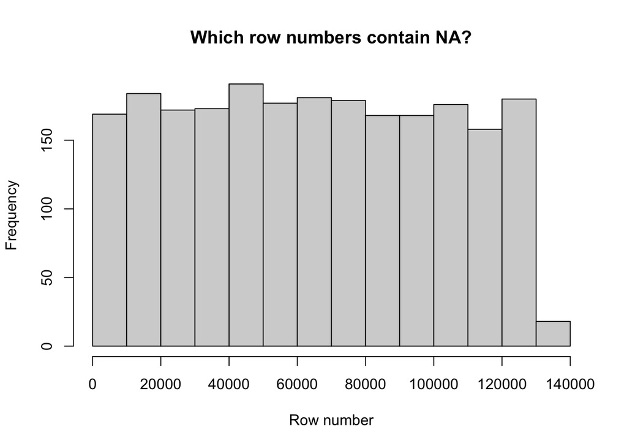

```r
hist(which(is.na(spotify_raw$master_metadata_track_name), arr.ind=TRUE), main = "Which row numbers contain NA?",  xlab= "Row number")
```

```r
#I see that the NA are randomly scattered

spotify <- spotify_raw |>
  select(ts, ms_played, conn_country, master_metadata_track_name, master_metadata_album_artist_name, master_metadata_album_album_name, spotify_track_uri, reason_start, reason_end, shuffle) |>
  drop_na() |>
  separate(ts, into = c("date", "time"), sep = "T") |>
  mutate(time = str_replace(time, "Z", "")) |>
  mutate(date = lubridate::as_date(date),
         time = lubridate::hms(time)) |>  #convert time to proper format
  separate(spotify_track_uri, into = c("rm1", "rm2", "track_id"), sep = ":") |>
  select(-c("rm1", "rm2"))  |>
  filter(date >= "2016-03-01")
```

```r
#This code was run only once to retrieve audio features. Output was saved as an RDS object in "cache/"

# track_id <- bind_cols(track_id = spotify$track_id,
#                       fl = gl(1285, k = 100)[1:128407]) |> #create factor levels to use group_split on
#   group_split(fl, .keep = FALSE)
#
# audio_features <- list()
#
# for (i in 1:length(track_id)) {
#   audio_features[[i]] <- spotifyr::get_track_audio_features(unlist(track_id[[i]]))
# }

#saveRDS(audio_features, "cache/audio_features.rds")
audio_features <- readRDS("cache/audio_features.rds")

audio_features <- data.table::rbindlist(audio_features) |>
  rename(track_id = id)

spotify <- bind_cols(spotify, audio_features) |>
  select(-c("track_id...24")) |>
  rename(track_id = "track_id...8")

#key, loudness, tempo, time signature are NOT 0 to 1

spotify <- spotify |>
  mutate(loudness_norm = (loudness - min(loudness))/(max(loudness)- min(loudness)),
         tempo_norm = (tempo - min(tempo))/(max(tempo)- min(tempo)),
         time_signature_norm = (time_signature - min(time_signature))/(max(time_signature) - min(time_signature))) |>
  select(-c(time, conn_country, reason_start, reason_end, type, uri, track_href, analysis_url, loudness, tempo, time_signature, speechiness)) |>
  filter(master_metadata_album_artist_name != "Mark Williams") |> #Meditation track
  relocate(17:19, .before = 16)

#I am going to remove 'key', I don't think it makes sense to keep it in, even normalized.
```

```r
spotify_daily <- spotify |>
  group_by(date) |>
  summarize(mins_daily = sum(ms_played)/60000,
            danceability_daily = mean(danceability),
            energy_daily = mean(energy),
            loudness_daily = mean(loudness_norm),
            acousticness_daily = mean(acousticness),
            instrumentalness_daily = mean(instrumentalness),
            liveness_daily = mean(liveness),
            valence_daily = mean(valence),
            tempo_daily = mean(tempo_norm))

daily_data <- full_join(spotify_daily, steps, join_by = "date") #introduce NA here, days where i have steps but no music data
daily_data <- filter(daily_data, date >= "2016-05-26" & date <= "2022-03-14") #Chose to filter from this date since I have extremely limited music data before this date

apply(daily_data, 2, VIM::countNA)
```

```
##                   date             mins_daily     danceability_daily
##                      0                     60                     60
##           energy_daily         loudness_daily     acousticness_daily
##                     60                     60                     60
## instrumentalness_daily         liveness_daily          valence_daily
##                     60                     60                     60
##            tempo_daily            steps_daily
##                     60                     26
```

```r
which(is.na(daily_data$mins_daily), arr.ind = TRUE)
```

```
##  [1] 2059 2060 2061 2062 2063 2064 2065 2066 2067 2068 2069 2070 2071 2072 2073
## [16] 2074 2075 2076 2077 2078 2079 2080 2081 2082 2083 2084 2085 2086 2087 2088
## [31] 2089 2090 2091 2092 2093 2094 2095 2096 2097 2098 2099 2100 2101 2102 2103
## [46] 2104 2105 2106 2107 2108 2109 2110 2111 2112 2113 2114 2115 2116 2117 2118
```

```r
#All NA are at the bottom of the dataset but the dates they span are random ie. MAR.

#I did not remove NA's from this data set. They're probably interesting...
```

```r
daily_data_scaled <- scale(daily_data[,2:11]) |>
  bind_cols(date = daily_data$date) |>
  relocate(date, .before = 1)
```

```r
set.seed(123)
train_daily <- sample_n(daily_data_scaled, 0.8*nrow(daily_data))
test_daily <- anti_join(daily_data_scaled, train_daily)
```

```r
rm(spotify_raw)
rm(spotify_daily)
rm(steps)
rm(audio_features)
```

## Exploratory Data Analysis

```r
gtsummary::tbl_summary(train_daily) |>
  modify_caption("Table 1. Summary table showing the median and the 25th, 75th percentile and the number of missing values.")
```

Table 1. Summary table showing the median and the 25th, 75th percentile and the number of missing values.

| **Characteristic** | **N = 1,694**<sup>1</sup> |
| --- | --- |
| date | 2016-05-26 to 2022-03-13 |
| mins_daily | -0.21 (-0.69, 0.46) |
| Unknown | 49 |
| danceability_daily | 0.03 (-0.58, 0.62) |
| Unknown | 49 |
| energy_daily | 0.20 (-0.37, 0.64) |
| Unknown | 49 |
| loudness_daily | 0.34 (-0.23, 0.61) |
| Unknown | 49 |
| acousticness_daily | -0.26 (-0.67, 0.28) |
| Unknown | 49 |
| instrumentalness_daily | -0.39 (-0.66, 0.25) |
| Unknown | 49 |
| liveness_daily | -0.07 (-0.60, 0.50) |
| Unknown | 49 |
| valence_daily | 0.11 (-0.47, 0.62) |
| Unknown | 49 |
| tempo_daily | -0.02 (-0.60, 0.58) |
| Unknown | 49 |
| steps_daily | -0.08 (-0.66, 0.53) |
| Unknown | 22 |

<sup>1</sup> Range; Median (IQR)

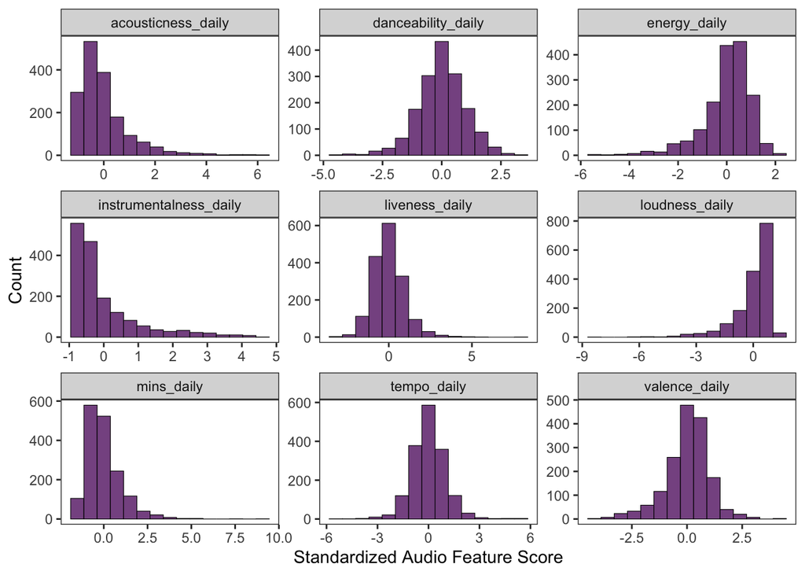

```r
train_daily |>
  select(2:11) |>
  pivot_longer(1:9) |>
  ggplot(aes(x = value)) +
  geom_histogram(fill = colors[[2]], color = "black", size = 0.2, bins = 15) +
  facet_wrap(~name, scales = "free", nrow = 3)  +
  labs(x = "Standardized Audio Feature Score",
       y = "Count") +
  theme(panel.grid = element_blank(),
        legend.position = "none")
```

```r
# God DAMN my tempo is almost perfectly normally distributed...
```

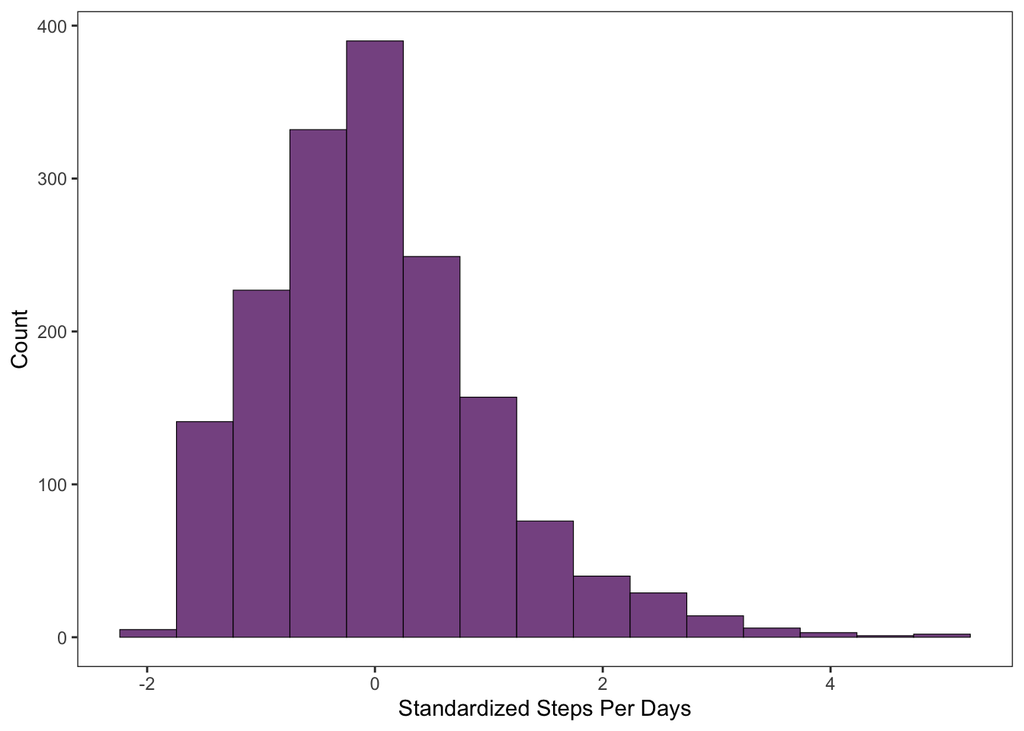

```r
train_daily |>
  select(steps_daily) |>
  #pivot_longer() |>
  ggplot(aes(x=steps_daily)) +
  geom_histogram(fill = colors[[2]], color = "black", size = 0.2,bins = 15) +
  #facet_wrap(~name, scales = "free") +
  labs(x = "Standardized Steps Per Days",
       y = "Count") +
  theme(panel.grid = element_blank(),
        legend.position = "none")
```

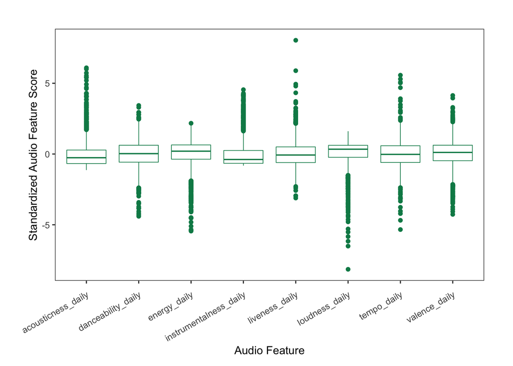

```r
train_daily |>
  select(1, 3:10) |>
  pivot_longer(2:9) |>
  ggplot(aes(x = name, y= value)) +
  geom_boxplot(color = colors[[8]], size = 0.3) +
  labs(x = "Audio Feature",
       y = "Standardized Audio Feature Score") +
  theme(axis.text.x = element_text(angle = 30, vjust = 0.9, hjust=1),
        plot.margin = margin(1,1,0.5,1, "cm"),
        axis.title.x.bottom = element_text(vjust = -1),
        panel.grid = element_blank())
```

```r
#library(xtable)
mcor <- cor(na.omit(train_daily[,2:10]))
upper<- round(mcor,2)
upper[upper.tri(mcor)]<-""
upper<-as.data.frame(upper)
names(upper) <- NULL
rownames(upper) <- NULL


headers <- c("mins", "danceability", "energy", "loudness ","acousticness", "instrumentalness", "liveness", "valence", "tempo")

names(upper) <- headers
rownames(upper) <- headers

knitr::kable(upper,
             caption = "Table 2. Correlation matrix. Note that large correlations indicate collinearity will be an issue for this dataset.")
```

Table 2. Correlation matrix. Note that large correlations indicate collinearity will be an issue for this dataset.

|  | mins | danceability | energy | loudness | acousticness | instrumentalness | liveness | valence | tempo |
| --- | --- | --- | --- | --- | --- | --- | --- | --- | --- |
| mins | 1 |  |  |  |  |  |  |  |  |
| danceability | -0.05 | 1 |  |  |  |  |  |  |  |
| energy | -0.18 | 0.33 | 1 |  |  |  |  |  |  |
| loudness | -0.2 | 0.51 | 0.93 | 1 |  |  |  |  |  |
| acousticness | 0.18 | -0.37 | -0.91 | -0.89 | 1 |  |  |  |  |
| instrumentalness | 0.21 | -0.5 | -0.76 | -0.84 | 0.72 | 1 |  |  |  |
| liveness | -0.07 | -0.02 | 0.44 | 0.35 | -0.37 | -0.31 | 1 |  |  |
| valence | -0.14 | 0.67 | 0.59 | 0.67 | -0.55 | -0.71 | 0.2 | 1 |  |
| tempo | -0.13 | -0.02 | 0.5 | 0.43 | -0.45 | -0.35 | 0.24 | 0.22 | 1 |

# Multiple Linear Regression

## Model Selection

```r
train_daily <- train_daily |>
  select(2:11)

lmod_steps <- lm(steps_daily ~ ., train_daily)

knitr::kable(broom::tidy(lmod_steps),
             caption = "Table 3. Summary output of full model.")
```

Table 3. Summary output of full model.

| term | estimate | std.error | statistic | p.value |
| --- | --- | --- | --- | --- |
| (Intercept) | 0.0126313 | 0.0238204 | 0.5302701 | 0.5959976 |
| mins_daily | 0.1023567 | 0.0242306 | 4.2242795 | 0.0000253 |
| danceability_daily | 0.1090230 | 0.0383118 | 2.8456769 | 0.0044877 |
| energy_daily | 0.0224230 | 0.0833593 | 0.2689925 | 0.7879699 |
| loudness_daily | 0.0610418 | 0.0880665 | 0.6931330 | 0.4883259 |
| acousticness_daily | 0.0318976 | 0.0620614 | 0.5139690 | 0.6073441 |
| instrumentalness_daily | -0.1238874 | 0.0469794 | -2.6370611 | 0.0084431 |
| liveness_daily | -0.0246289 | 0.0281724 | -0.8742193 | 0.3821290 |
| valence_daily | -0.0747324 | 0.0410748 | -1.8194213 | 0.0690325 |
| tempo_daily | -0.0878685 | 0.0280103 | -3.1370132 | 0.0017376 |

```r
model_selection <- ols_step_both_aic(lmod_steps)
#model_selection <- ols_step_all_possible(lmod_steps)
#both ols_step_all_possible and ols_step_both_aic select the same model

#plot(model_selection$aic)

lmod_steps_aic <- lm(steps_daily ~ mins_daily + danceability_daily + instrumentalness_daily + tempo_daily, data = train_daily)

#summary(lmod_steps_aic)
knitr::kable(broom::tidy(lmod_steps_aic),
             caption = "Table 4. A summary table for the model selected by AIC.")
```

Table 4. A summary table for the model selected by AIC.

| term | estimate | std.error | statistic | p.value |
| --- | --- | --- | --- | --- |
| (Intercept) | 0.0118426 | 0.0238096 | 0.4973885 | 0.6189827 |
| mins_daily | 0.1025099 | 0.0241273 | 4.2487073 | 0.0000227 |
| danceability_daily | 0.0884765 | 0.0284540 | 3.1094572 | 0.0019070 |
| instrumentalness_daily | -0.1183174 | 0.0306224 | -3.8637510 | 0.0001161 |
| tempo_daily | -0.0852325 | 0.0259413 | -3.2855915 | 0.0010395 |

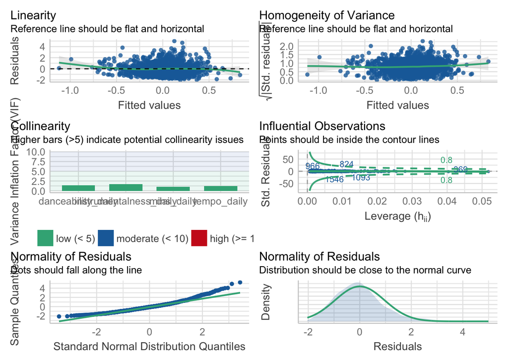

```r
performance::check_model(lmod_steps_aic)
```

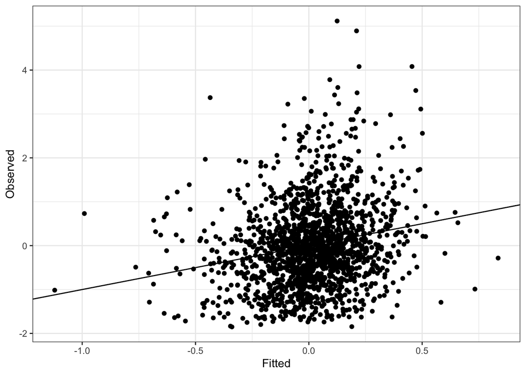

```r
fitted_obs_aic <- as.data.frame(cbind(fitted = fitted(lmod_steps_aic),
                                  obs = na.omit(train_daily)$steps_daily))

ggplot(fitted_obs_aic, aes(x= fitted, y = obs)) +
  geom_point() +
  geom_abline(intercept = 0, slope = 1) +
  labs(x = "Fitted",
       y= "Observed")
```

```r
# plot(fitted(lmod_steps_aic), na.omit(train_daily)$steps_daily)
# abline(1,1)
```

### Selecting BIC Based Model

```r
regs <- leaps::regsubsets(steps_daily ~ ., data = train_daily)
regs <- summary(regs)

#plot(regs$bic)

lmod_steps_bic <- lm(steps_daily ~ tempo_daily + mins_daily + instrumentalness_daily, data = train_daily)
#summary(lmod_steps_bic)
knitr::kable(broom::tidy(lmod_steps_bic),
             caption = "A summary table for the model selected by BIC.")
```

A summary table for the model selected by BIC.

| term | estimate | std.error | statistic | p.value |
| --- | --- | --- | --- | --- |
| (Intercept) | 0.0116906 | 0.0238732 | 0.4896965 | 0.6244150 |
| tempo_daily | -0.1044216 | 0.0252639 | -4.1332272 | 0.0000376 |
| mins_daily | 0.1068414 | 0.0241515 | 4.4238053 | 0.0000103 |
| instrumentalness_daily | -0.1704491 | 0.0256937 | -6.6338836 | 0.0000000 |

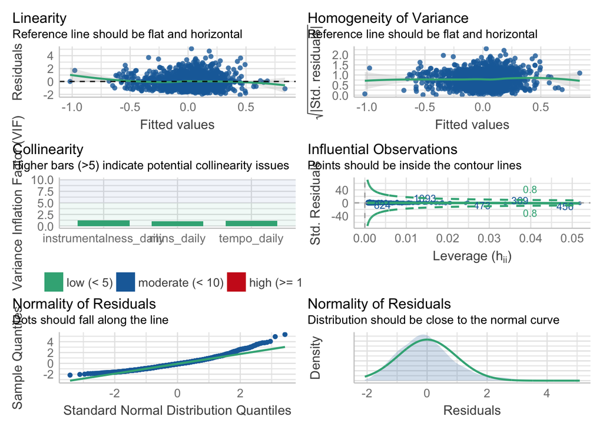

```r
performance::check_model(lmod_steps_bic)
```

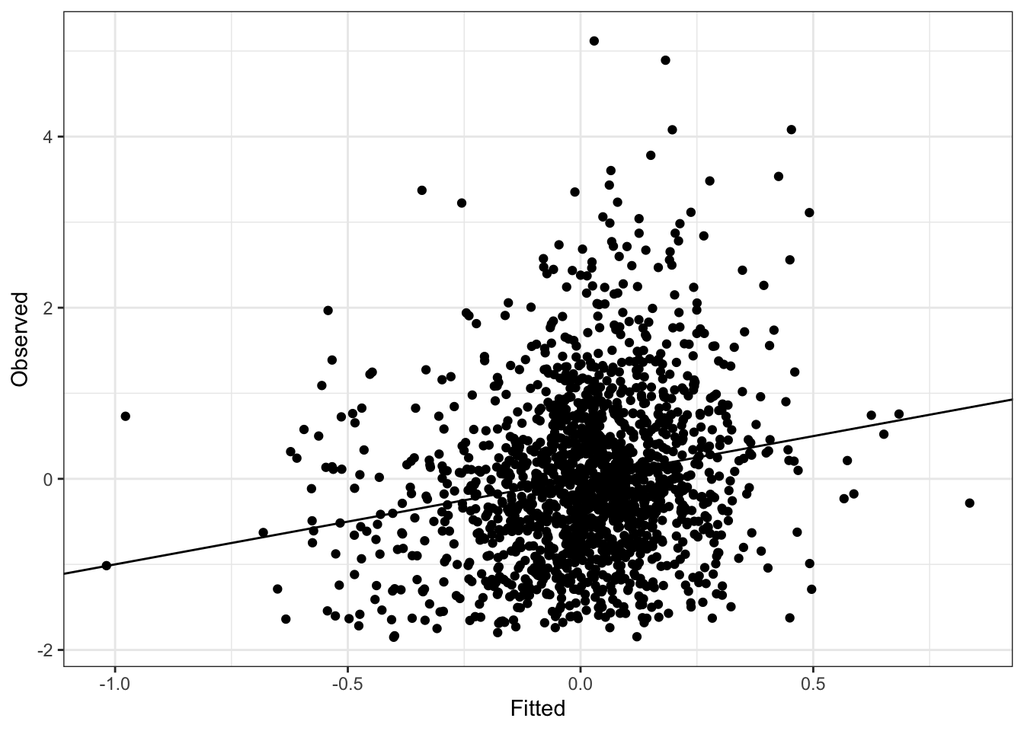

```r
fitted_obs_bic <- as.data.frame(cbind(fitted = fitted(lmod_steps_bic),
                                  obs= na.omit(train_daily)$steps_daily))

ggplot(fitted_obs_bic, aes(x= fitted, y = obs)) +
  geom_point() +
  geom_abline(intercept = 0, slope = 1) +
  labs(x = "Fitted",
       y= "Observed")
```

### Model Comparison

```r
#Mean Squared Prediction Error
mspe_aic <- mean((test_daily$steps_daily - predict.lm(lmod_steps_aic, test_daily))^2, na.rm = TRUE)
mspe_bic <- mean((test_daily$steps_daily - predict.lm(lmod_steps_bic, test_daily))^2, na.rm = TRUE)
mspe_aic
```

```
## [1] 1.005988
```

```r
mspe_bic
```

```
## [1] 1.010227
```

```r
# knitr::kable(tibble(mspe_aic, mspe_bic),
#              caption = "MSPE for both MLR models.")
#
# mod_comp <- performance::compare_performance(lmod_steps_aic, lmod_steps_bic)
# knitr::kable(mod_comp,
#              caption = "Overall metrics for model comparison.")
```

## Model Interpretation

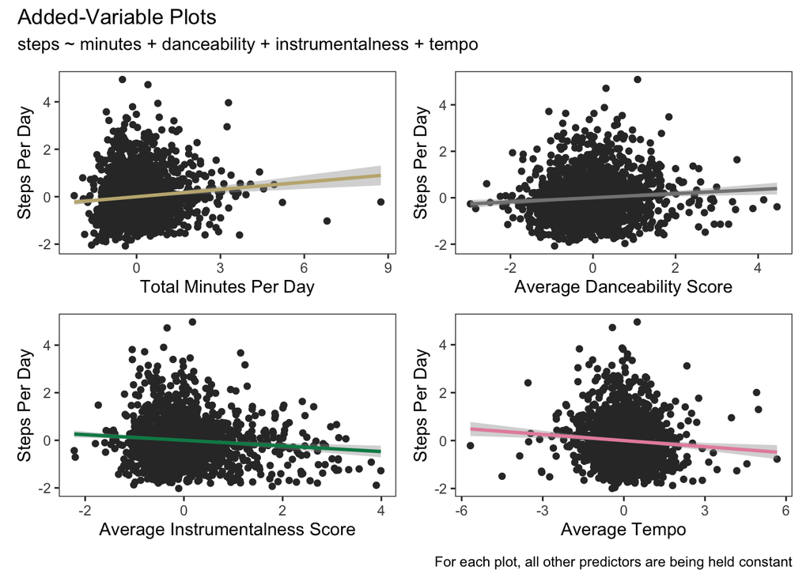

Added variable plots for best model.

# Principle Component Analysis

```r
train_daily_pc <- train_daily |>
  select(-steps_daily) |>
  na.omit()

pca_rec <- recipe(~., data = train_daily_pc) |> #no outcome formula
  step_pca(all_predictors()) #do pca

pca_prep <- prep(pca_rec) #actually run the recipe

pca_tidy_coef <- recipes::tidy(pca_prep, type = "coef", 1) #variable loadings
pca_tidy_var <- recipes::tidy(pca_prep, type = "variance", 1) #variance
```

```r
knitr::kable(head(pca_tidy_coef), caption = "Table 8a. Main outputs of the tidymodels PCA analysis, contains the variable loadings (b) contains the variances.")
```

Table 8a. Main outputs of the tidymodels PCA analysis, contains the variable loadings (b) contains the variances.

| terms | value | component | id |
| --- | --- | --- | --- |
| mins_daily | -0.1148316 | PC1 | pca_oO4oJ |
| danceability_daily | 0.2536793 | PC1 | pca_oO4oJ |
| energy_daily | 0.4261728 | PC1 | pca_oO4oJ |
| loudness_daily | 0.4405361 | PC1 | pca_oO4oJ |
| acousticness_daily | -0.4088556 | PC1 | pca_oO4oJ |
| instrumentalness_daily | -0.4070513 | PC1 | pca_oO4oJ |

```r
knitr::kable(head(pca_tidy_var), caption = "Table 8b. Main outputs of the tidymodels PCA analysis, contains the variances.")
```

Table 8b. Main outputs of the tidymodels PCA analysis, contains the variances.

| terms | value | component | id |
| --- | --- | --- | --- |
| variance | 4.8039030 | 1 | pca_oO4oJ |
| variance | 1.3283516 | 2 | pca_oO4oJ |
| variance | 0.9763173 | 3 | pca_oO4oJ |
| variance | 0.7298864 | 4 | pca_oO4oJ |
| variance | 0.5158676 | 5 | pca_oO4oJ |
| variance | 0.3051506 | 6 | pca_oO4oJ |

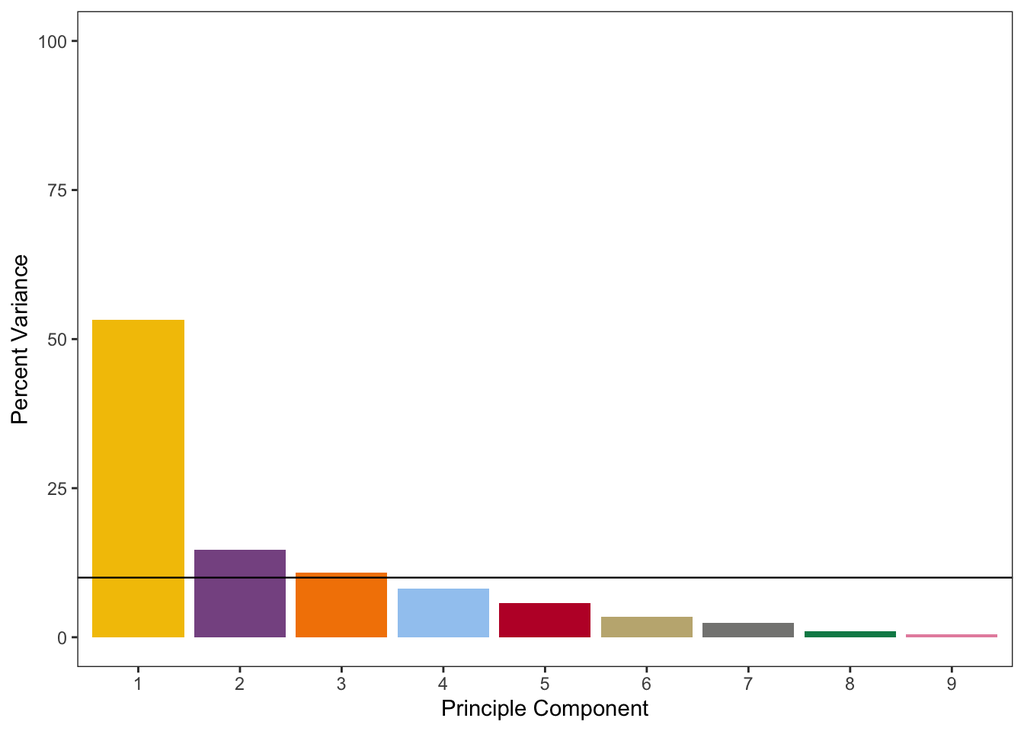

```r
pca_tidy_var |>
  filter(terms == "percent variance") |>
  mutate(component = fct_inorder(as.character(component))) |>
  ggplot(aes(x = component, y = value)) +
  geom_col(aes(fill = component)) +
  scale_fill_manual(values = colors) +
  geom_hline(yintercept = 10, size = 0.4) +
  theme_bw() +
  theme(legend.position = "none",
        panel.grid = element_blank()) +
  scale_y_continuous(limits = c(0,100)) +
  labs(x = "Principle Component",
       y = "Percent Variance")
```

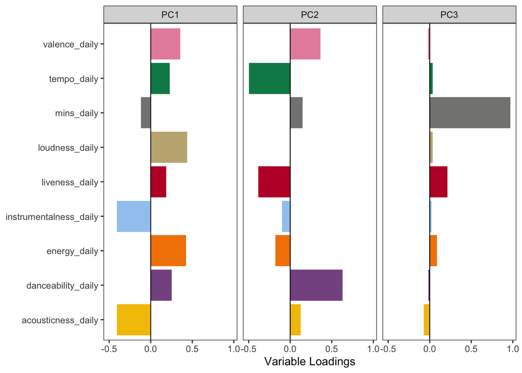

```r
pca_tidy_coef |>
  filter(component %in% paste0("PC", 1:3)) |>
  mutate(component = fct_inorder(component)) |>
  ggplot(aes(value, terms, fill = terms)) +
  scale_fill_manual(values = colors) +
  geom_col(show.legend = FALSE) +
  geom_vline(xintercept = 0, linetype = 1, size = 0.4) +
  facet_wrap(~component, nrow = 1) +
  labs(y = NULL,
       x = "Variable Loadings") +
  theme_bw() +
  theme(panel.grid = element_blank())
```

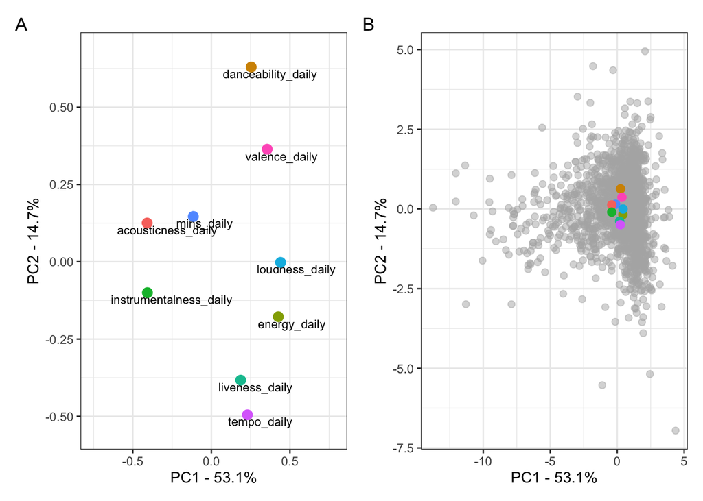

```r
pc1 <- pca_tidy_coef |>
  filter(component %in% c("PC1", "PC2")) |>
  pivot_wider(names_from = component, values_from = value) |>
ggplot(aes(x=PC1, y=PC2, label = terms)) +
  geom_text(hjust = 0.3, vjust = 1.3, size = 3) +
  geom_point(aes(color = terms), show.legend = F, size = 3) +
  scale_fill_manual(values = colors) +
  xlab(paste("PC1 - ", "53.1", "%", sep="")) +
  ylab(paste("PC2 - ", "14.7", "%", sep="")) +
  scale_x_continuous(expand = expansion(0.5)) +
  scale_y_continuous(expand = expansion(0.1)) +
  theme_bw()

pc2 <- pca_tidy_coef |>
  filter(component %in% c("PC1", "PC2")) |>
  pivot_wider(names_from = component, values_from = value) |>
ggplot(aes(x=PC1, y=PC2)) +
  geom_point(juice(pca_prep), mapping = aes(PC1, PC2), alpha = 0.5, size = 2, color = "grey70") +
   geom_point(aes(color = terms), show.legend = F, size = 2.5) +
  scale_fill_manual(values = colors) +
  xlab(paste("PC1 - ", "53.1", "%", sep="")) +
  ylab(paste("PC2 - ", "14.7", "%", sep="")) +
  #scale_x_continuous(expand = expansion(0.5)) +
  theme_bw()

pc1 + pc2 + patchwork::plot_annotation(tag_level = 'A')
```

## Supplementary Information

#### S1. Audio Features

acousticness– 0 to 1; 1 is high confidence track is acoustic

danceability– 0 to 1; 0 is least danceable, 1 is most danceable

energy– 0 to 1; 1 is high energy

instrumentalness– 0 to 1; values above 0.5 represent instrumental tracks, the closer the score to 1 the higher confidence

loudness– in decibels. loudness ranges between -60 and 0 dB. 0 db is loud, -60 is quiet

mode– major is 1; minor is 0

tempo = bpm

time signature– number 3-7 indicating 3/4, 4,4, etc

liveness– 0 to 1; probability track was played lived. value > 0.8 high prob of live

valence– 0 to 1; 1= happy, 0 = sad

https://developer.spotify.com/documentation/web-api/reference/#/operations/get-several-audio-features

#### S2.

```r
lmod_stepwise <- ols_step_both_p(lmod_steps) #chooses a model by p-value
lmod_steps_stepwise <- lm(steps_daily ~ mins_daily + danceability_daily + instrumentalness_daily + tempo_daily, data = train_daily)
#plot(lmod_stepwise$aic)
summary(lmod_steps_stepwise)
```

```
##
## Call:
## lm(formula = steps_daily ~ mins_daily + danceability_daily +
##     instrumentalness_daily + tempo_daily, data = train_daily)
##
## Residuals:
##     Min      1Q  Median      3Q     Max
## -2.0351 -0.6685 -0.0918  0.5024  4.9932
##
## Coefficients:
##                        Estimate Std. Error t value Pr(>|t|)
## (Intercept)             0.01184    0.02381   0.497 0.618983
## mins_daily              0.10251    0.02413   4.249 2.27e-05 ***
## danceability_daily      0.08848    0.02845   3.109 0.001907 **
## instrumentalness_daily -0.11832    0.03062  -3.864 0.000116 ***
## tempo_daily            -0.08523    0.02594  -3.286 0.001039 **
## ---
## Signif. codes:  0 '***' 0.001 '**' 0.01 '*' 0.05 '.' 0.1 ' ' 1
##
## Residual standard error: 0.9591 on 1618 degrees of freedom
##   (71 observations deleted due to missingness)
## Multiple R-squared:  0.04232,    Adjusted R-squared:  0.03996
## F-statistic: 17.88 on 4 and 1618 DF,  p-value: 2.256e-14
```

#### S3.

```r
unscale <- function(estimate, predictor_name) {
  predictor_name <- predictor_name
  estimate * sd(predictor_name, na.rm = TRUE) + mean(predictor_name, na.rm = TRUE)
}

unscale(-0.001453, daily_data$steps_daily)
```

```
## [1] 6874.39
```

#### S4.

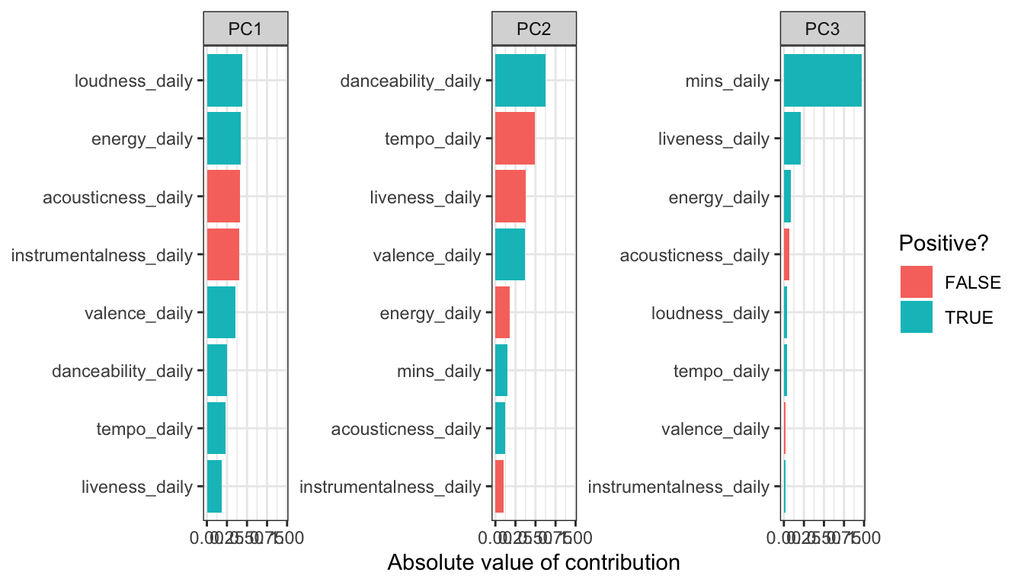

```r
pca_tidy_coef  |>
  filter(component %in% paste0("PC", 1:3)) |>
  group_by(component) |>
  top_n(8, abs(value)) |>
  ungroup() |>
  mutate(terms = reorder_within(terms, abs(value), component)) |>
  ggplot(aes(abs(value), terms, fill = value > 0)) +
  geom_col() +
  facet_wrap(~component, scales = "free_y", nrow = 1) +
  theme_bw() +
  scale_y_reordered() +
  labs(
    x = "Absolute value of contribution",
    y = NULL, fill = "Positive?"
  )
```

```r
# juice(pca_prep) |>
#   ggplot(aes(PC1, PC2)) +
#   geom_point(alpha = 0.7, size = 2) +
#   # geom_text(check_overlap = TRUE, hjust = "inward", family = "IBMPlexSans") +
#   labs(color = NULL)
```

## Refrences

[@tidy_2019]

Zaharatos, B. 2022, *Module4-annotated* [Lecture Slides]. STAT 5010. Univerity of Colorado Boulder.

Zaharatos, B. 2022, *Module1-1-annotated* [Lecture Slides]. STAT 5010. Univerity of Colorado Boulder.

Zaharatos, B. 2022, *Module1-2-annotated* [Lecture Slides]. STAT 5010. Univerity of Colorado Boulder.

Zaharatos, B. 2022, *Module3-annotated* [Lecture Slides]. STAT 5010. Univerity of Colorado Boulder.